# Pertemuan 1 - Pemulusan

Hakim Zoelva Mahesa

## Library / Packages

*Package* R yang akan digunakan pada perkuliahan Analisis Deret Waktu sesi UTS adalah: `forecast`, `graphics`, `TTR`, `TSA` . Jika *package* tersebut belum ada, silakan install terlebih dahulu.

```r
#install.packages("forecast")
#install.packages("graphics")
#install.packages("TTR")
#install.packages("TSA")
```

Jika sudah ada, silakan panggil library *package* tersebut.

```r
library("forecast")
```

```r
library("graphics")
library("TTR")
library("TSA")
```

## Impor Data

```r
#install.packages("rio") #install jika belum ada
library(rio)
datampdwp1 <- import("https://raw.githubusercontent.com/hakimzoelvamahesa/mpdw/main/Data/harga%20saham%20samsung%202013-2023.csv")
```

## Eksplorasi Data

Melihat data menggunakan fungsi `View()`, struktur data menggunakan fungsi `str()`, dan dimensi data menggunakan fungsi `dim()`.

```r
View(datampdwp1)
str(datampdwp1)
```

```
## 'data.frame':    519 obs. of  2 variables:
##  $ Date : chr  "30/08/2013 15:30:00" "06/09/2013 15:30:00" "13/09/2013 15:30:00" "17/09/2013 15:30:00" ...
##  $ Close: int  27360 27380 28120 27720 27320 28360 28860 29440 28980 30000 ...
```

```r
dim(datampdwp1)
```

```
## [1] 519   2
```

Mengubah data agar terbaca sebagai data deret waktu dengan fungsi `ts()` .

```r
datampdwp1.ts <- ts(datampdwp1$Close)
```

Menampilkan ringkasan data

```r
summary(datampdwp1.ts)
```

```
##    Min. 1st Qu.  Median    Mean 3rd Qu.    Max.
##   21620   28560   46900   47363   60150   88800
```

Membuat plot data deret waktu

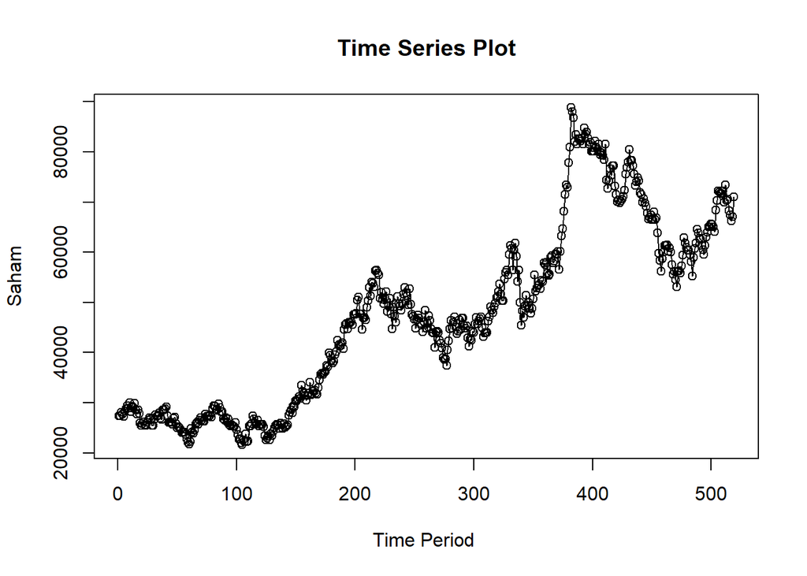

```r
ts.plot(datampdwp1.ts, xlab="Time Period ", ylab="Saham",
        main = "Time Series Plot")
points(datampdwp1.ts)
```

Menyimpan plot

```r
#menyimpan plot
#dev.copy(png, "eksplorasi.png")
#dev.off()
```

## Single Moving Average & Double Moving Average

### Pembagian Data

Pembagian data latih dan data uji dilakukan dengan perbandingan 80% data latih dan 20% data uji.

```r
#membagi data latih dan data uji
training_ma <- datampdwp1[1:415,]
testing_ma <- datampdwp1[416:519,]
train_ma.ts <- ts(training_ma$Close)
test_ma.ts <- ts(testing_ma$Close)
```

### Eksplorasi Data

Eksplorasi data dilakukan pada keseluruhan data, data latih serta data uji menggunakan plot data deret waktu.

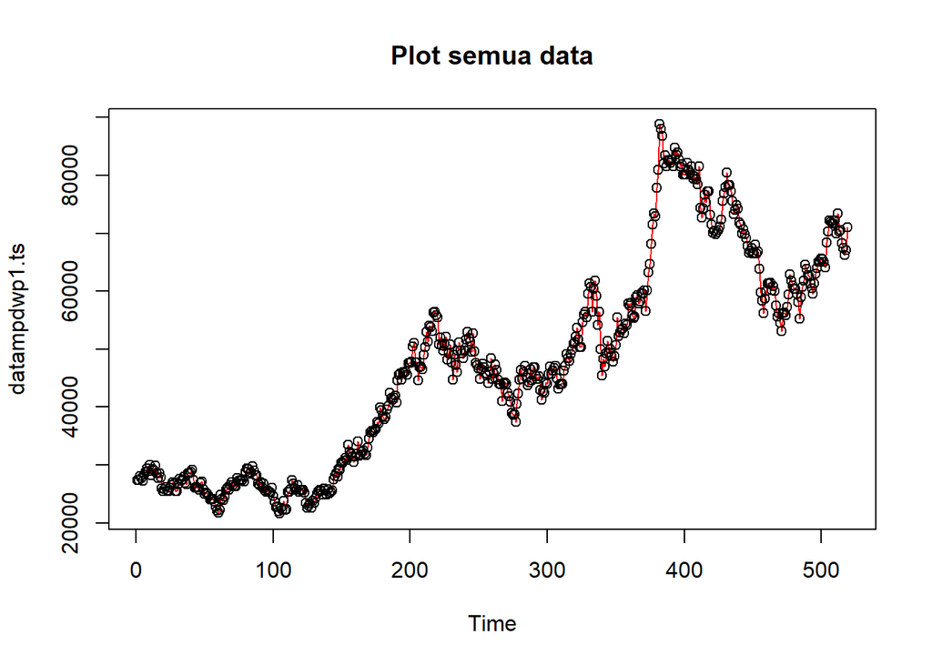

```r
#eksplorasi keseluruhan data
plot(datampdwp1.ts, col="red",main="Plot semua data")
points(datampdwp1.ts)
```

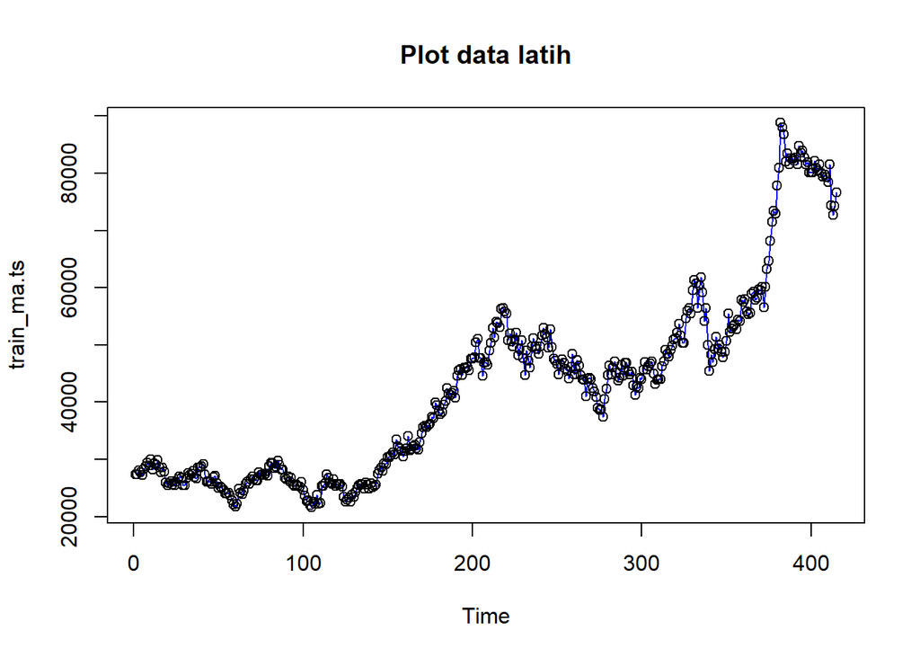

```r
#eksplorasi data latih
plot(train_ma.ts, col="blue",main="Plot data latih")
points(train_ma.ts)
```

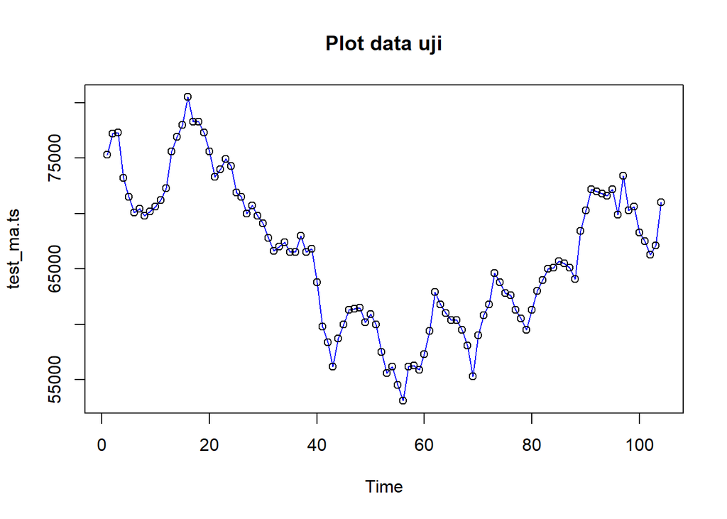

```r
#eksplorasi data uji
plot(test_ma.ts, col="blue",main="Plot data uji")
points(test_ma.ts)
```

### Single Moving Average (SMA)

Ide dasar dari Single Moving Average (SMA) adalah data suatu periode dipengaruhi oleh data periode sebelumnya. Metode pemulusan ini cocok digunakan untuk pola data stasioner atau konstan. Prinsip dasar metode pemulusan ini adalah data pemulusan pada periode ke-t merupakan rata rata dari m buah data pada periode ke-t hingga periode ke (t-m+1). Data pemulusan pada periode ke-t selanjutnya digunakan sebagai nilai peramalan pada periode ke t+1

Pemulusan menggunakan metode SMA dilakukan dengan fungsi `SMA()`. Dalam hal ini akan dilakukan pemulusan dengan parameter `m=4`.

```r
data.sma<-SMA(train_ma.ts, n=4)
data.sma
```

```
## Time Series:
## Start = 1
## End = 415
## Frequency = 1
##   [1]      NA      NA      NA 27645.0 27635.0 27880.0 28065.0 28495.0 28910.0
##  [10] 29320.0 29155.0 29105.0 29110.0 29080.0 29170.0 28810.0 28695.0 28205.0
##  [19] 27545.0 26955.0 26280.0 25835.0 25755.0 25770.0 25815.0 25930.0 26275.0
##  [28] 26595.0 26465.0 26180.0 26110.0 26315.0 26765.0 27290.0 27610.0 27440.0
##  [37] 27290.0 27540.0 27685.0 28170.0 28780.0 28475.0 27840.0 27180.0 26425.0
##  [46] 26010.0 26220.0 26440.0 26370.0 26200.0 25790.0 25250.0 24960.0 24715.0
##  [55] 24415.0 24230.0 23985.0 23685.0 23205.0 22600.0 22235.0 22750.0 23255.0
##  [64] 23780.0 24335.0 24550.0 25030.0 25490.0 26015.0 26340.0 26480.0 26620.0
##  [73] 26560.0 26730.0 26905.0 27195.0 27420.0 27375.0 27335.0 27685.0 28235.0
##  [82] 28670.0 28990.0 28950.0 29045.0 28975.0 28920.0 28800.0 28040.0 27420.0
##  [91] 27120.0 26605.0 26620.0 26375.0 25955.0 25810.0 25445.0 25355.0 25550.0
```

[output cut: 36 more lines]

Data pemulusan pada periode ke-t selanjutnya digunakan sebagai nilai peramalan pada periode ke t+1 sehingga hasil peramalan 1 periode kedepan adalah sebagai berikut.

```r
data.ramal<-c(NA,data.sma)
data.ramal #forecast 1 periode ke depan
```

```
##   [1]      NA      NA      NA      NA 27645.0 27635.0 27880.0 28065.0 28495.0
##  [10] 28910.0 29320.0 29155.0 29105.0 29110.0 29080.0 29170.0 28810.0 28695.0
##  [19] 28205.0 27545.0 26955.0 26280.0 25835.0 25755.0 25770.0 25815.0 25930.0
##  [28] 26275.0 26595.0 26465.0 26180.0 26110.0 26315.0 26765.0 27290.0 27610.0
##  [37] 27440.0 27290.0 27540.0 27685.0 28170.0 28780.0 28475.0 27840.0 27180.0
##  [46] 26425.0 26010.0 26220.0 26440.0 26370.0 26200.0 25790.0 25250.0 24960.0
##  [55] 24715.0 24415.0 24230.0 23985.0 23685.0 23205.0 22600.0 22235.0 22750.0
##  [64] 23255.0 23780.0 24335.0 24550.0 25030.0 25490.0 26015.0 26340.0 26480.0
##  [73] 26620.0 26560.0 26730.0 26905.0 27195.0 27420.0 27375.0 27335.0 27685.0
##  [82] 28235.0 28670.0 28990.0 28950.0 29045.0 28975.0 28920.0 28800.0 28040.0
##  [91] 27420.0 27120.0 26605.0 26620.0 26375.0 25955.0 25810.0 25445.0 25355.0
## [100] 25550.0 25305.0 24890.0 24275.0 23450.0 22810.0 22290.0 22255.0 22130.0
## [109] 22575.0 22730.0 22680.0 23455.0 23830.0 24715.0 25980.0 26320.0 26495.0
## [118] 26475.0 26250.0 25905.0 25825.0 25790.0 25580.0 25535.0 24970.0 24240.0
## [127] 23565.0 23085.0 22880.0 23170.0 23280.0 23535.0 24130.0 24545.0 25125.0
```

[output cut: 32 more lines]

Selanjutnya akan dilakukan peramalan sejumlah data uji yaitu 104 periode. Pada metode SMA, hasil peramalan 104 periode ke depan akan bernilai sama dengan hasil peramalan 1 periode kedepan. Dalam hal ini akan dilakukan pengguabungan data aktual train, data hasil pemulusan dan data hasil ramalan 104 periode kedepan.

```r
data.gab<-cbind(aktual=c(train_ma.ts,rep(NA,104)),pemulusan=c(data.sma,rep(NA,104)),ramalan=c(data.ramal,rep(data.ramal[length(data.ramal)],104)))
data.gab #forecast 104 periode ke depan
```

```
##        aktual pemulusan ramalan
##   [1,]  27360        NA      NA
##   [2,]  27380        NA      NA
##   [3,]  28120        NA      NA
##   [4,]  27720   27645.0      NA
##   [5,]  27320   27635.0 27645.0
##   [6,]  28360   27880.0 27635.0
##   [7,]  28860   28065.0 27880.0
##   [8,]  29440   28495.0 28065.0
##   [9,]  28980   28910.0 28495.0
##  [10,]  30000   29320.0 28910.0
##  [11,]  28200   29155.0 29320.0
##  [12,]  29240   29105.0 29155.0
##  [13,]  29000   29110.0 29105.0
##  [14,]  29880   29080.0 29110.0
```

[output cut: 506 more lines]

Adapun plot data deret waktu dari hasil peramalan yang dilakukan adalah sebagai berikut.

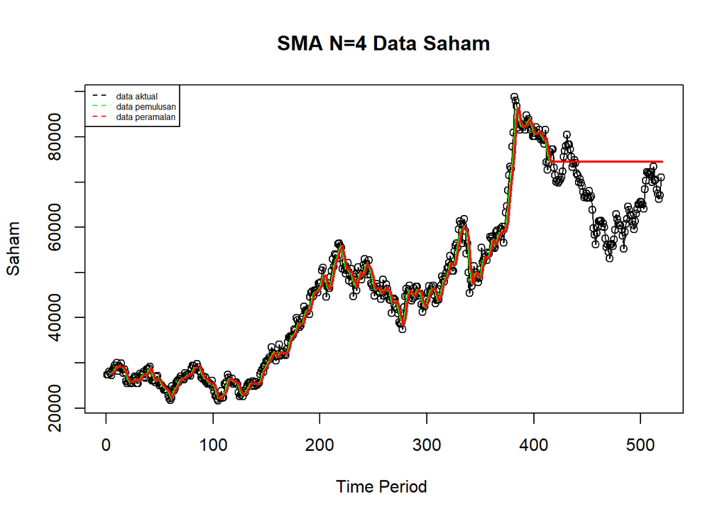

```r
ts.plot(datampdwp1.ts, xlab="Time Period ", ylab="Saham", main= "SMA N=4 Data Saham")
points(datampdwp1.ts)
lines(data.gab[,2],col="green",lwd=2)
lines(data.gab[,3],col="red",lwd=2)
legend("topleft",c("data aktual","data pemulusan","data peramalan"), lty=8, col=c("black","green","red"), cex=0.5)
```

Selanjutnya perhitungan akurasi dilakukan dengan ukuran akurasi *Sum Squares Error* (SSE), *Mean Square Error* (MSE) dan *Mean Absolute Percentage Error* (MAPE). Perhitungan akurasi dilakukan baik pada data latih maupun pada data uji.

```r
#Menghitung nilai keakuratan data latih
error_train.sma = train_ma.ts-data.ramal[1:length(train_ma.ts)]
SSE_train.sma = sum(error_train.sma[5:length(train_ma.ts)]^2)
MSE_train.sma = mean(error_train.sma[5:length(train_ma.ts)]^2)
MAPE_train.sma = mean(abs((error_train.sma[5:length(train_ma.ts)]/train_ma.ts[5:length(train_ma.ts)])*100))

akurasi_train.sma <- matrix(c(SSE_train.sma, MSE_train.sma, MAPE_train.sma))
row.names(akurasi_train.sma)<- c("SSE", "MSE", "MAPE")
colnames(akurasi_train.sma) <- c("Akurasi m = 4")
akurasi_train.sma
```

```
##      Akurasi m = 4
## SSE   1.966197e+09
## MSE   4.783934e+06
## MAPE  3.647657e+00
```

Dalam hal ini nilai MAPE data latih pada metode pemulusan SMA kurang dari 5%, nilai ini dapat dikategorikan sebagai nilai akurasi yang sangat baik. Selanjutnya dilakukan perhitungan nilai MAPE data uji pada metode pemulusan SMA.

```r
#Menghitung nilai keakuratan data uji
error_test.sma = test_ma.ts-data.gab[416:519,3]
SSE_test.sma = sum(error_test.sma^2)
MSE_test.sma = mean(error_test.sma^2)
MAPE_test.sma = mean(abs((error_test.sma/test_ma.ts*100)))

akurasi_test.sma <- matrix(c(SSE_test.sma, MSE_test.sma, MAPE_test.sma))
row.names(akurasi_test.sma)<- c("SSE", "MSE", "MAPE")
colnames(akurasi_test.sma) <- c("Akurasi m = 4")
akurasi_test.sma
```

```
##      Akurasi m = 4
## SSE   1.144090e+10
## MSE   1.100087e+08
## MAPE  1.425941e+01
```

### Double Moving Average (DMA)

Metode pemulusan Double Moving Average (DMA) pada dasarnya mirip dengan SMA. Namun demikian, metode ini lebih cocok digunakan untuk pola data trend. Proses pemulusan dengan rata rata dalam metode ini dilakukan sebanyak 2 kali.

```r
dma <- SMA(data.sma, n = 4)
At <- 2*data.sma - dma
Bt <- 2/(4-1)*(data.sma - dma)
data.dma<- At+Bt
data.ramal2<- c(NA, data.dma)

t = 1:104
f = c()

for (i in t) {
  f[i] = At[length(At)] + Bt[length(Bt)]*(i)
}

data.gab2 <- cbind(aktual = c(train_ma.ts,rep(NA,104)), pemulusan1 = c(data.sma,rep(NA,104)),pemulusan2 = c(data.dma, rep(NA,104)),At = c(At, rep(NA,104)), Bt = c(Bt,rep(NA,104)),ramalan = c(data.ramal2, f[-1]))
data.gab2
```

```
##        aktual pemulusan1 pemulusan2       At           Bt   ramalan
##   [1,]  27360         NA         NA       NA           NA        NA
##   [2,]  27380         NA         NA       NA           NA        NA
##   [3,]  28120         NA         NA       NA           NA        NA
##   [4,]  27720    27645.0         NA       NA           NA        NA
##   [5,]  27320    27635.0         NA       NA           NA        NA
##   [6,]  28360    27880.0         NA       NA           NA        NA
##   [7,]  28860    28065.0   28496.25 28323.75   172.500000        NA
##   [8,]  29440    28495.0   29288.75 28971.25   317.500000  28496.25
##   [9,]  28980    28910.0   29864.17 29482.50   381.666667  29288.75
##  [10,]  30000    29320.0   30357.50 29942.50   415.000000  29864.17
##  [11,]  28200    29155.0   29463.33 29340.00   123.333333  30357.50
##  [12,]  29240    29105.0   29075.83 29087.50   -11.666667  29463.33
##  [13,]  29000    29110.0   29005.83 29047.50   -41.666667  29075.83
##  [14,]  29880    29080.0   29025.83 29047.50   -21.666667  29005.83
```

[output cut: 505 more lines]

Hasil pemulusan menggunakan metode DMA divisualisasikan sebagai berikut

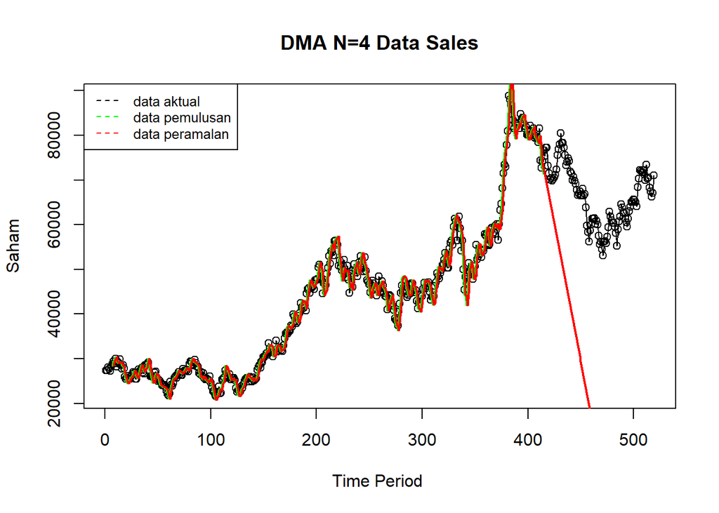

```r
ts.plot(datampdwp1.ts, xlab="Time Period ", ylab="Saham", main= "DMA N=4 Data Sales")
points(datampdwp1.ts)
lines(data.gab2[,3],col="green",lwd=2)
lines(data.gab2[,6],col="red",lwd=2)
legend("topleft",c("data aktual","data pemulusan","data peramalan"), lty=8, col=c("black","green","red"), cex=0.8)
```

Selanjutnya perhitungan akurasi dilakukan baik pada data latih maupun data uji. Perhitungan akurasi dilakukan dengan ukuran akurasi SSE, MSE dan MAPE.

```r
#Menghitung nilai keakuratan data latih
error_train.dma = train_ma.ts-data.ramal2[1:length(train_ma.ts)]
SSE_train.dma = sum(error_train.dma[8:length(train_ma.ts)]^2)
MSE_train.dma = mean(error_train.dma[8:length(train_ma.ts)]^2)
MAPE_train.dma = mean(abs((error_train.dma[8:length(train_ma.ts)]/train_ma.ts[8:length(train_ma.ts)])*100))

akurasi_train.dma <- matrix(c(SSE_train.dma, MSE_train.dma, MAPE_train.dma))
row.names(akurasi_train.dma)<- c("SSE", "MSE", "MAPE")
colnames(akurasi_train.dma) <- c("Akurasi m = 4")
akurasi_train.dma
```

```
##      Akurasi m = 4
## SSE   1.821235e+09
## MSE   4.463812e+06
## MAPE  3.611423e+00
```

Perhitungan akurasi pada data latih menggunakan nilai MAPE menghasilkan nilai MAPE yang kurang dari 10% sehingga dikategorikan sangat baik. Selanjutnya, perhitungan nilai akurasi dilakukan pada data uji.

```r
#Menghitung nilai keakuratan data uji
error_test.dma = test_ma.ts-data.gab2[416:519,6]
SSE_test.dma = sum(error_test.dma^2)
MSE_test.dma = mean(error_test.dma^2)
MAPE_test.dma = mean(abs((error_test.dma/test_ma.ts*100)))

akurasi_test.dma <- matrix(c(SSE_test.dma, MSE_test.dma, MAPE_test.dma))
row.names(akurasi_test.dma)<- c("SSE", "MSE", "MAPE")
colnames(akurasi_test.dma) <- c("Akurasi m = 4")
akurasi_test.dma
```

```
##      Akurasi m = 4
## SSE   4.858366e+11
## MSE   4.671506e+09
## MAPE  9.028196e+01
```

## Single Exponential Smoothing & Double Exponential Smoothing

Metode *Exponential Smoothing* adalah metode pemulusan dengan melakukan pembobotan menurun secara eksponensial. Nilai yang lebih baru diberi bobot yang lebih besar dari nilai terdahulu. Terdapat satu atau lebih parameter pemulusan yang ditentukan secara eksplisit, dan hasil pemilihan parameter tersebut akan menentukan bobot yang akan diberikan pada nilai pengamatan. Ada dua macam model, yaitu model tunggal dan ganda.

### Pembagian Data

Pembagian data latih dan data uji dilakukan dengan perbandingan 80% data latih dan 20% data uji.

```r
#membagi training dan testing
training<-datampdwp1[1:415,]
testing<-datampdwp1[416:519,]
train.ts <- ts(training$Close)
test.ts <- ts(testing$Close)
```

### Eksplorasi

Eksplorasi dilakukan dengan membuat plot data deret waktu untuk keseluruhan data, data latih, dan data uji.

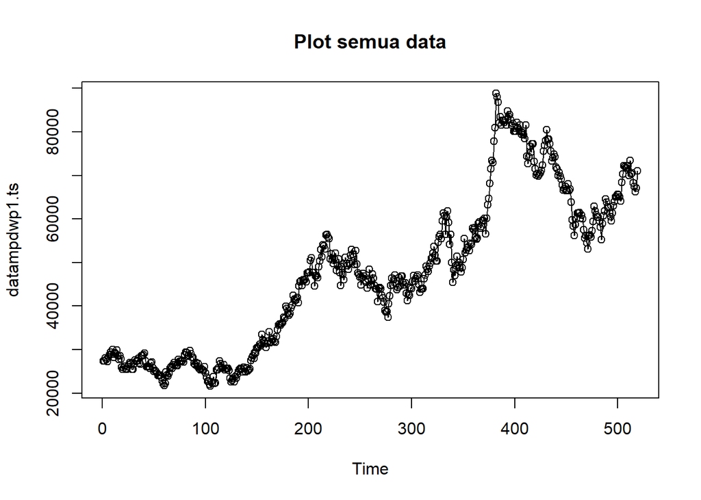

```r
#eksplorasi data
plot(datampdwp1.ts, col="black",main="Plot semua data")
points(datampdwp1.ts)
```

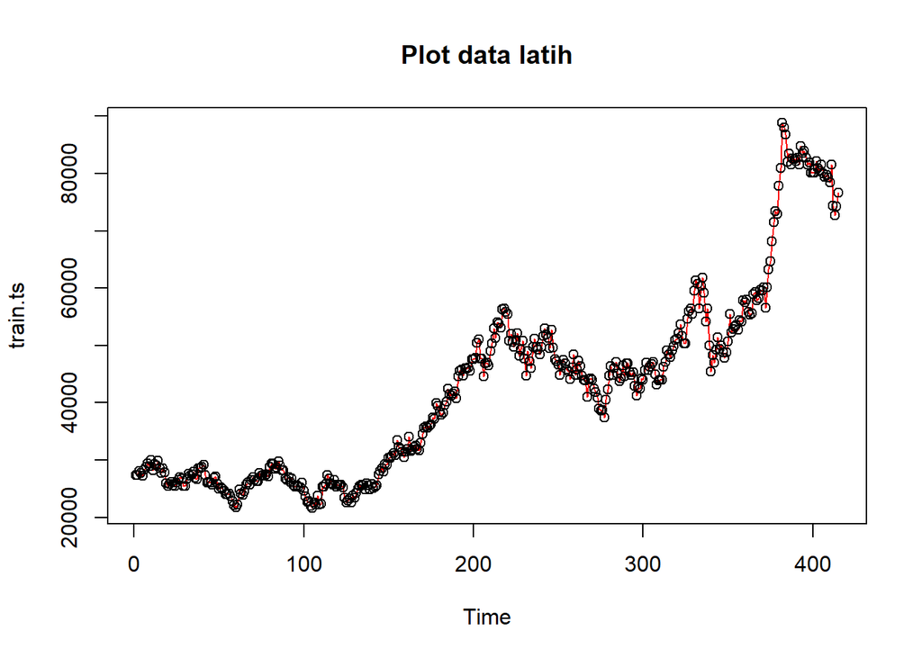

```r
plot(train.ts, col="red",main="Plot data latih")
points(train.ts)
```

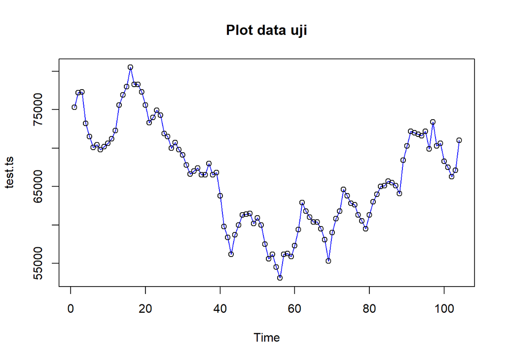

```r
plot(test.ts, col="blue",main="Plot data uji")
points(test.ts)
```

Pemulusan dengan metode SES dapat dilakukan dengan dua fungsi dari *packages* berbeda, yaitu (1) fungsi `ses()` dari *packages* `forecast` dan (2) fungsi `HoltWinters` dari *packages* `stats` .

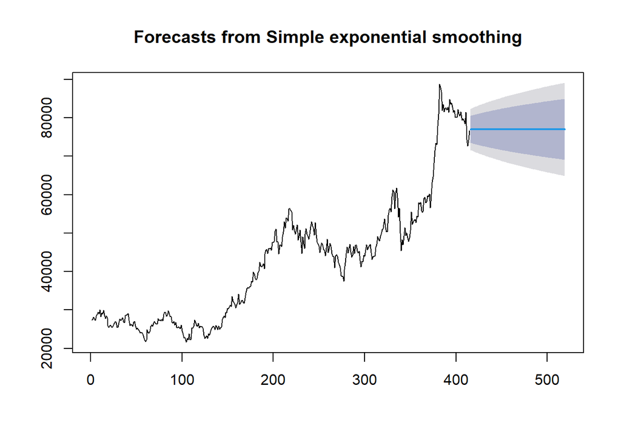

```r
#Cara 1 (fungsi ses)
ses.1 <- ses(train.ts, h = 104, alpha = 0.2)
plot(ses.1)
```

```r
ses.1
```

```
##     Point Forecast    Lo 80    Hi 80    Lo 95    Hi 95
## 416       76997.78 73500.64 80494.92 71649.37 82346.19
## 417       76997.78 73431.39 80564.18 71543.45 82452.11
## 418       76997.78 73363.45 80632.11 71439.55 82556.01
## 419       76997.78 73296.76 80698.80 71337.56 82658.01
## 420       76997.78 73231.25 80764.31 71237.37 82758.19
## 421       76997.78 73166.86 80828.70 71138.89 82856.67
## 422       76997.78 73103.53 80892.03 71042.04 82953.52
## 423       76997.78 73041.22 80954.34 70946.74 83048.82
## 424       76997.78 72979.88 81015.69 70852.92 83142.64
## 425       76997.78 72919.45 81076.11 70760.52 83235.05
## 426       76997.78 72859.91 81135.65 70669.46 83326.10
## 427       76997.78 72801.22 81194.35 70579.69 83415.87
## 428       76997.78 72743.33 81252.23 70491.16 83504.40
## 429       76997.78 72686.22 81309.34 70403.82 83591.74
```

[output cut: 90 more lines]

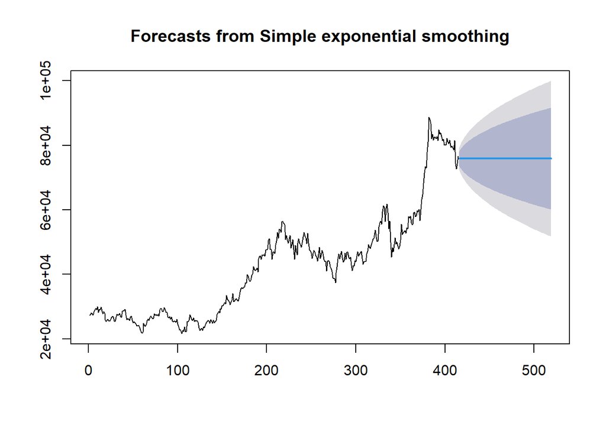

```r
ses.2<- ses(train.ts, h = 104, alpha = 0.7)
plot(ses.2)
```

```r
ses.2
```

```
##     Point Forecast    Lo 80    Hi 80    Lo 95    Hi 95
## 416       75862.81 73665.23 78060.38 72501.91 79223.71
## 417       75862.81 73180.32 78545.29 71760.30 79965.31
## 418       75862.81 72770.54 78955.07 71133.60 80592.01
## 419       75862.81 72409.05 79316.57 70580.74 81144.87
## 420       75862.81 72081.96 79643.66 70080.49 81645.12
## 421       75862.81 71780.99 79944.62 69620.21 82105.40
## 422       75862.81 71500.75 80224.87 69191.61 82534.00
## 423       75862.81 71237.45 80488.17 68788.93 82936.68
## 424       75862.81 70988.35 80737.26 68407.97 83317.64
## 425       75862.81 70751.38 80974.23 68045.55 83680.06
## 426       75862.81 70524.92 81200.70 67699.21 84026.40
## 427       75862.81 70307.68 81417.93 67366.97 84358.64
## 428       75862.81 70098.62 81626.99 67047.25 84678.36
## 429       75862.81 69896.89 81828.72 66738.72 84986.89
```

[output cut: 90 more lines]

Untuk mendapatkan gambar hasil pemulusan pada data latih dengan fungsi `ses()` , perlu digunakan fungsi `autoplot()` dan `autolayer()` dari *library packages* `ggplot2` .

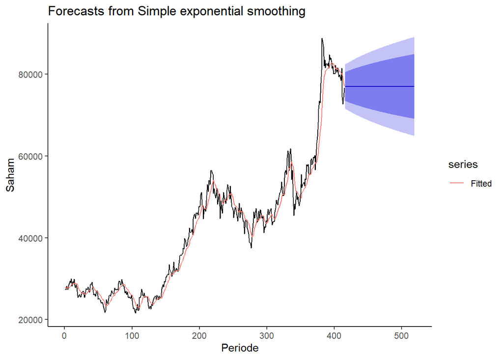

```r
library(ggplot2)
autoplot(ses.1) +
  autolayer(fitted(ses.1), series="Fitted") +
  ylab("Saham") + xlab("Periode") + theme_classic()
```

Pada fungsi `ses()` , terdapat beberapa argumen yang umum digunakan, yaitu nilia `y` , `gamma` , `beta` , `alpha` , dan `h` .

Nilai `y` adalah nilai data deret waktu, `gamma` adalah parameter pemulusan untuk komponen musiman, `beta` adalah parameter pemulusan untuk tren, dan `alpha` adalah parameter pemulusan untuk stasioner, serta `h` adalah banyaknya periode yang akan diramalkan.

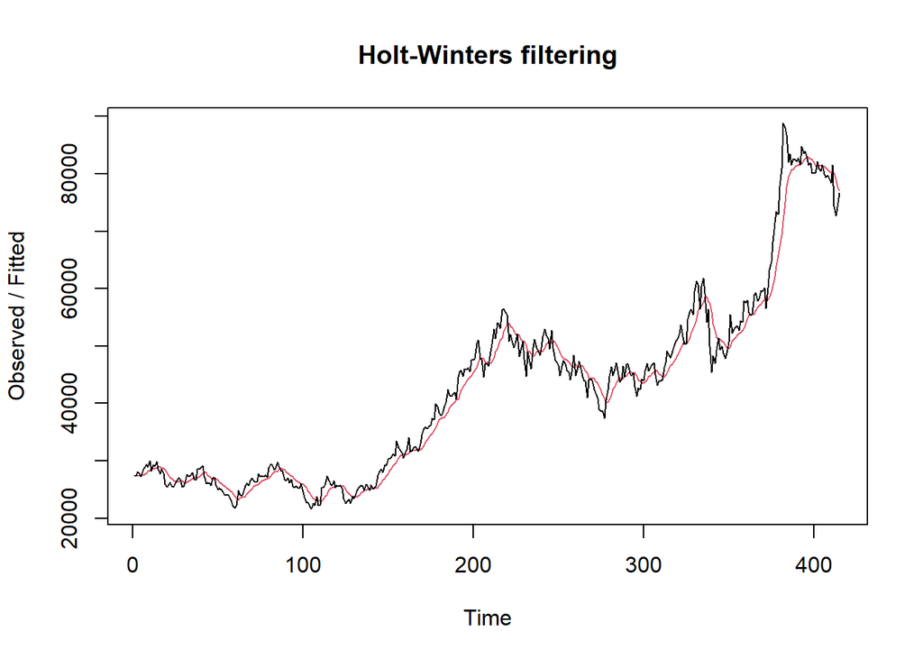

```r
#Cara 2 (fungsi Holtwinter)
ses1<- HoltWinters(train.ts, gamma = FALSE, beta = FALSE, alpha = 0.2)
plot(ses1)
```

```r
#ramalan
ramalan1<- forecast(ses1, h=104)
ramalan1
```

```
##     Point Forecast    Lo 80    Hi 80    Lo 95    Hi 95
## 416       76997.78 73585.72 80409.84 71779.49 82216.07
## 417       76997.78 73518.15 80477.41 71676.15 82319.41
## 418       76997.78 73451.87 80543.69 71574.78 82420.79
## 419       76997.78 73386.80 80608.76 71475.26 82520.30
## 420       76997.78 73322.88 80672.68 71377.51 82618.05
## 421       76997.78 73260.06 80735.50 71281.43 82714.13
## 422       76997.78 73198.28 80797.29 71186.94 82808.62
## 423       76997.78 73137.48 80858.08 71093.96 82901.60
## 424       76997.78 73077.63 80917.93 71002.42 82993.14
## 425       76997.78 73018.67 80976.89 70912.26 83083.30
## 426       76997.78 72960.58 81034.98 70823.42 83172.14
## 427       76997.78 72903.31 81092.25 70735.83 83259.73
## 428       76997.78 72846.84 81148.73 70649.46 83346.10
## 429       76997.78 72791.12 81204.45 70564.24 83431.32
```

[output cut: 90 more lines]

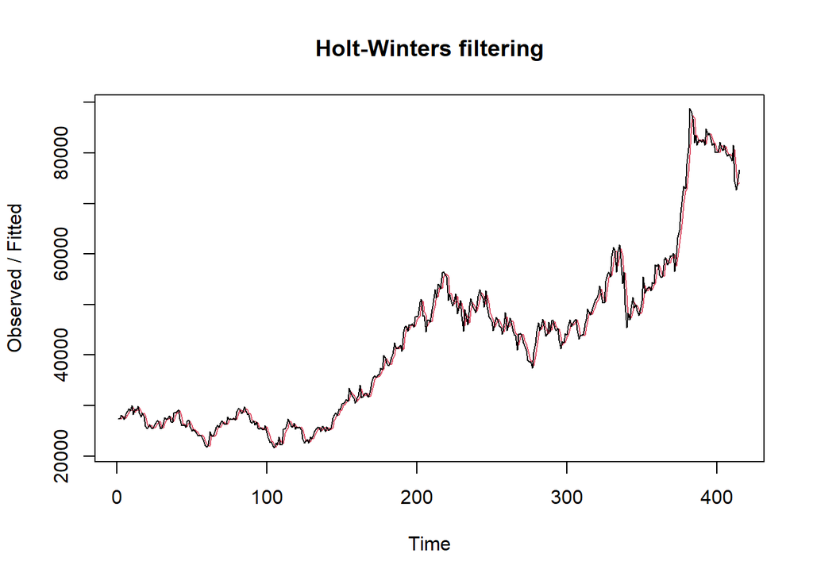

```r
ses2<- HoltWinters(train.ts, gamma = FALSE, beta = FALSE, alpha = 0.7)
plot(ses2)
```

```r
#ramalan
ramalan2<- forecast(ses2, h=104)
ramalan2
```

```
##     Point Forecast    Lo 80    Hi 80    Lo 95    Hi 95
## 416       75862.81 73675.75 78049.87 72517.99 79207.63
## 417       75862.81 73193.16 78532.45 71779.93 79945.68
## 418       75862.81 72785.34 78940.27 71156.23 80569.39
## 419       75862.81 72425.57 79300.04 70606.01 81119.60
## 420       75862.81 72100.05 79625.57 70108.16 81617.45
## 421       75862.81 71800.52 79925.09 69650.08 82075.53
## 422       75862.81 71521.62 80204.00 69223.53 82502.08
## 423       75862.81 71259.58 80466.04 68822.77 82902.84
## 424       75862.81 71011.67 80713.94 68443.64 83281.98
## 425       75862.81 70775.83 80949.78 68082.95 83642.66
## 426       75862.81 70550.45 81175.16 67738.27 83987.35
## 427       75862.81 70334.26 81391.36 67407.62 84317.99
## 428       75862.81 70126.20 81599.41 67089.42 84636.19
## 429       75862.81 69925.43 81800.18 66782.37 84943.24
```

[output cut: 90 more lines]

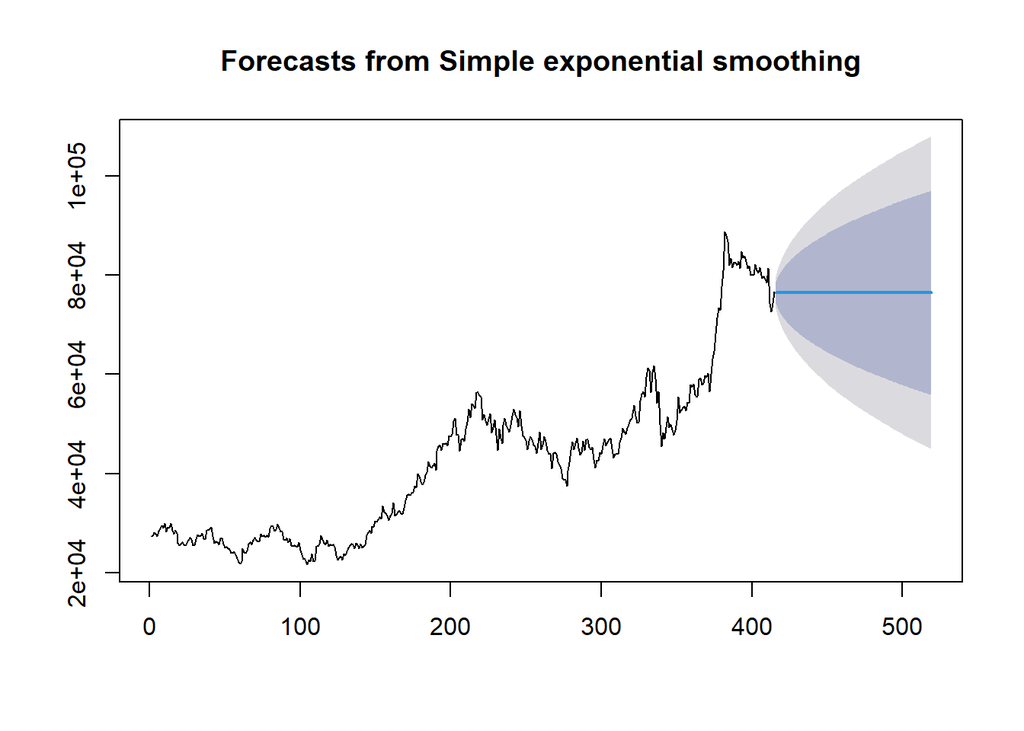

```r
#SES
ses.opt <- ses(train.ts, h = 104, alpha = NULL)
plot(ses.opt)
```

```r
ses.opt
```

```
##     Point Forecast    Lo 80    Hi 80    Lo 95     Hi 95
## 416       76475.44 74346.64 78604.24 73219.72  79731.16
## 417       76475.44 73542.64 79408.23 71990.12  80960.76
## 418       76475.44 72915.84 80035.04 71031.50  81919.38
## 419       76475.44 72383.95 80566.92 70218.05  82732.83
## 420       76475.44 71913.67 81037.21 69498.81  83452.06
## 421       76475.44 71487.53 81463.35 68847.09  84103.79
## 422       76475.44 71095.04 81855.84 68246.82  84704.05
## 423       76475.44 70729.29 82221.59 67687.46  85263.41
## 424       76475.44 70385.47 82565.41 67161.64  85789.24
## 425       76475.44 70060.05 82890.83 66663.95  86286.93
## 426       76475.44 69750.36 83200.52 66190.32  86760.56
## 427       76475.44 69454.31 83496.56 65737.56  87213.32
## 428       76475.44 69170.26 83780.62 65303.13  87647.75
## 429       76475.44 68896.84 84054.04 64884.97  88065.90
```

[output cut: 90 more lines]

```r
#Lamda Optimum Holt Winter
sesopt<- HoltWinters(train.ts, gamma = FALSE, beta = FALSE,alpha = NULL)
sesopt
```

```
## Holt-Winters exponential smoothing without trend and without seasonal component.
##
## Call:
## HoltWinters(x = train.ts, alpha = NULL, beta = FALSE, gamma = FALSE)
##
## Smoothing parameters:
##  alpha: 0.9476524
##  beta : FALSE
##  gamma: FALSE
##
## Coefficients:
##       [,1]
## a 76475.51
```

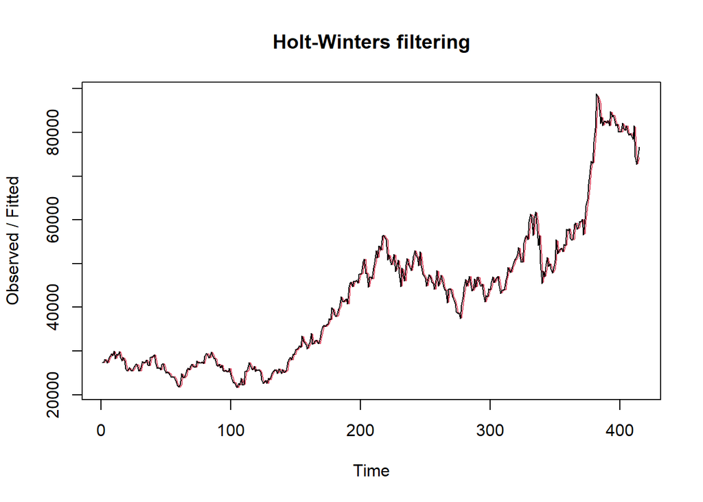

```r
plot(sesopt)
```

```r
#ramalan
ramalanopt<- forecast(sesopt, h=104)
ramalanopt
```

```
##     Point Forecast    Lo 80    Hi 80    Lo 95     Hi 95
## 416       76475.51 74352.78 78598.24 73229.08  79721.95
## 417       76475.51 73551.04 79399.99 72002.91  80948.11
## 418       76475.51 72925.98 80025.04 71046.98  81904.05
## 419       76475.51 72395.60 80555.43 70235.82  82715.21
## 420       76475.51 71926.63 81024.39 69518.60  83432.42
## 421       76475.51 71501.69 81449.33 68868.71  84082.31
## 422       76475.51 71110.30 81840.72 68270.13  84680.89
## 423       76475.51 70745.59 82205.44 67712.35  85238.68
## 424       76475.51 70402.74 82548.29 67188.00  85763.02
## 425       76475.51 70078.23 82872.79 66691.72  86259.31
## 426       76475.51 69769.41 83181.61 66219.42  86731.61
## 427       76475.51 69474.20 83476.82 65767.93  87183.09
## 428       76475.51 69190.94 83760.08 65334.73  87616.30
## 429       76475.51 68918.30 84032.73 64917.75  88033.28
```

[output cut: 90 more lines]

Setelah dilakukan peramalan, akan dilakukan perhitungan keakuratan hasil peramalan. Perhitungan akurasi ini dilakukan baik pada data latih dan data uji.

#### Akurasi Data Latih

Perhitungan akurasi data dapat dilakukan dengan cara langsung maupun manual. Secara langsung, nilai akurasi dapat diambil dari objek yang tersimpan pada hasil SES, yaitu *sum of squared errors* (SSE). Nilai akurasi lain dapat dihitung pula dari nilai SSE tersebut.

```r
#Keakuratan Metode
#Pada data training
SSE1<-ses1$SSE
MSE1<-ses1$SSE/length(train.ts)
RMSE1<-sqrt(MSE1)

akurasi1 <- matrix(c(SSE1,MSE1,RMSE1))
row.names(akurasi1)<- c("SSE", "MSE", "RMSE")
colnames(akurasi1) <- c("Akurasi lamda=0.2")
akurasi1
```

```
##      Akurasi lamda=0.2
## SSE       3.076376e+09
## MSE       7.412954e+06
## RMSE      2.722674e+03
```

```r
SSE2<-ses2$SSE
MSE2<-ses2$SSE/length(train.ts)
RMSE2<-sqrt(MSE2)

akurasi2 <- matrix(c(SSE2,MSE2,RMSE2))
row.names(akurasi2)<- c("SSE", "MSE", "RMSE")
colnames(akurasi2) <- c("Akurasi lamda=0.7")
akurasi2
```

```
##      Akurasi lamda=0.7
## SSE       1.214413e+09
## MSE       2.926297e+06
## RMSE      1.710642e+03
```

```r
#Cara Manual
fitted1<-ramalan1$fitted
sisaan1<-ramalan1$residuals
head(sisaan1)
```

```
## Time Series:
## Start = 1
## End = 6
## Frequency = 1
## [1]       NA   20.000  756.000  204.800 -236.160  851.072
```

```r
resid1<-training$Close-ramalan1$fitted
head(resid1)
```

```
## Time Series:
## Start = 1
## End = 6
## Frequency = 1
## [1]       NA   20.000  756.000  204.800 -236.160  851.072
```

```r
#Cara Manual
SSE.1=sum(sisaan1[2:length(train.ts)]^2)
SSE.1
```

```
## [1] 3076376102
```

```r
MSE.1 = SSE.1/length(train.ts)
MSE.1
```

```
## [1] 7412954
```

```r
MAPE.1 = sum(abs(sisaan1[2:length(train.ts)]/train.ts[2:length(train.ts)])*
               100)/length(train.ts)
MAPE.1
```

```
## [1] 4.465395
```

```r
akurasi.1 <- matrix(c(SSE.1,MSE.1,MAPE.1))
row.names(akurasi.1)<- c("SSE", "MSE", "MAPE")
colnames(akurasi.1) <- c("Akurasi lamda=0.2")
akurasi.1
```

```
##      Akurasi lamda=0.2
## SSE       3.076376e+09
## MSE       7.412954e+06
## MAPE      4.465395e+00
```

```r
fitted2<-ramalan2$fitted
sisaan2<-ramalan2$residuals
head(sisaan2)
```

```
## Time Series:
## Start = 1
## End = 6
## Frequency = 1
## [1]       NA   20.000  746.000 -176.200 -452.860  904.142
```

```r
resid2<-training$Close-ramalan2$fitted
head(resid2)
```

```
## Time Series:
## Start = 1
## End = 6
## Frequency = 1
## [1]       NA   20.000  746.000 -176.200 -452.860  904.142
```

```r
SSE.2=sum(sisaan2[2:length(train.ts)]^2)
SSE.2
```

```
## [1] 1214413391
```

```r
MSE.2 = SSE.2/length(train.ts)
MSE.2
```

```
## [1] 2926297
```

```r
MAPE.2 = sum(abs(sisaan2[2:length(train.ts)]/train.ts[2:length(train.ts)])*
               100)/length(train.ts)
MAPE.2
```

```
## [1] 2.84127
```

```r
akurasi.2 <- matrix(c(SSE.2,MSE.2,MAPE.2))
row.names(akurasi.2)<- c("SSE", "MSE", "MAPE")
colnames(akurasi.2) <- c("Akurasi lamda=0.7")
akurasi.2
```

```
##      Akurasi lamda=0.7
## SSE       1.214413e+09
## MSE       2.926297e+06
## MAPE      2.841270e+00
```

#### Akurasi Data Uji

Akurasi data uji dapat dihitung dengan cara yang hampir sama dengan perhitungan akurasi data latih.

```r
selisih1<-ramalan1$mean-testing$Close
SSEtesting1<-sum(selisih1^2)
MSEtesting1<-SSEtesting1/length(testing)

selisih2<-ramalan2$mean-testing$Close
SSEtesting2<-sum(selisih2^2)
MSEtesting2<-SSEtesting2/length(testing)

selisihopt<-ramalanopt$mean-testing$Close
SSEtestingopt<-sum(selisihopt^2)
MSEtestingopt<-SSEtestingopt/length(testing)

akurasitesting1 <- matrix(c(SSEtesting1,SSEtesting2,SSEtestingopt))
row.names(akurasitesting1)<- c("SSE1", "SSE2", "SSEopt")
akurasitesting1
```

```
##               [,1]
## SSE1   16354956400
## SSE2   13961180454
## SSEopt 15220160000
```

```r
akurasitesting2 <- matrix(c(MSEtesting1,MSEtesting2,MSEtestingopt))
row.names(akurasitesting2)<- c("MSE1", "MSE2", "MSEopt")
akurasitesting2
```

```
##              [,1]
## MSE1   8177478200
## MSE2   6980590227
## MSEopt 7610080000
```

Selain dengan cara di atas, perhitungan nilai akurasi dapat menggunakan fungsi `accuracy()` dari *package* `forecast` . Penggunaannya yaitu dengan menuliskan `accuracy(hasil ramalan, kondisi aktual)` . Contohnya adalah sebagai berikut.

```r
#cara lain
accuracy(ramalanopt,testing$Close)
```

```
##                       ME      RMSE       MAE         MPE      MAPE      MASE
## Training set    125.1899  1659.104  1194.071   0.1940718  2.785884 0.9979118
## Test set     -10185.1276 12097.425 10415.818 -16.4992728 16.792307 8.7047290
##                      ACF1
## Training set -0.003809987
## Test set               NA
```

### DES

Metode pemulusan *Double Exponential Smoothing* (DES) digunakan untuk data yang memiliki pola tren. Metode DES adalah metode semacam SES, hanya saja dilakukan dua kali, yaitu pertama untuk tahapan ‘level’ dan kedua untuk tahapan ‘tren’. Pemulusan menggunakan metode ini akan menghasilkan peramalan tidak konstan untuk periode berikutnya.

Pemulusan dengan metode DES kali ini akan menggunakan fungsi `HoltWinters()` . Jika sebelumnya nilai argumen `beta` dibuat `FALSE` , kali ini argumen tersebut akan diinisialisasi bersamaan dengan nilai `alpha` .

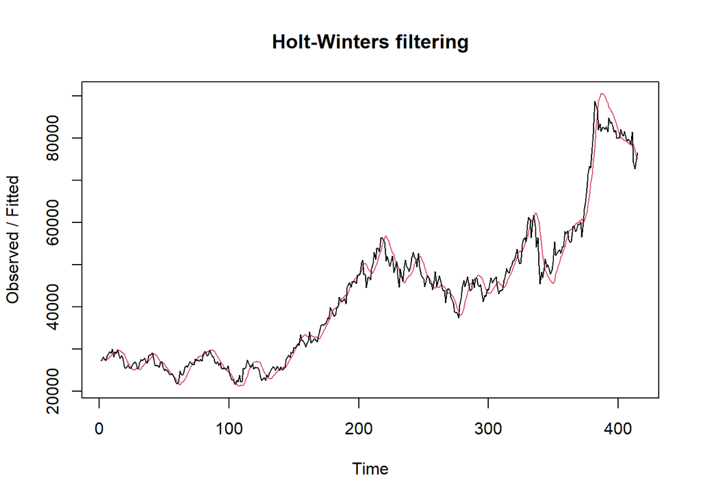

```r
#Lamda=0.2 dan gamma=0.2
des.1<- HoltWinters(train.ts, gamma = FALSE, beta = 0.2, alpha = 0.2)
plot(des.1)
```

```r
#ramalan
ramalandes1<- forecast(des.1, h=104)
ramalandes1
```

```
##     Point Forecast       Lo 80     Hi 80        Lo 95     Hi 95
## 416       74812.54  71358.9815  78266.10   69530.7768  80094.31
## 417       74269.67  70718.0433  77821.31   68837.9234  79701.43
## 418       73726.81  70045.8870  77407.73   68097.3261  79356.29
## 419       73183.94  69340.6973  77027.18   67306.2086  79061.67
## 420       72641.07  68601.7322  76680.41   66463.4360  78818.70
## 421       72098.20  67829.1759  76367.23   65569.2901  78627.11
## 422       71555.33  67023.9249  76086.74   64625.1420  78485.53
## 423       71012.47  66187.3578  75837.57   63633.1000  78391.83
## 424       70469.60  65321.1270  75618.07   62595.6913  78343.50
## 425       69926.73  64426.9947  75426.46   61515.6110  78337.85
## 426       69383.86  63506.7164  75261.01   60395.5439  78372.18
## 427       68840.99  62561.9674  75120.02   59238.0519  78443.93
## 428       68298.13  61594.3017  75001.95   58045.5119  78550.74
## 429       67755.26  60605.1347  74905.38   56820.0887  78690.43
```

[output cut: 90 more lines]

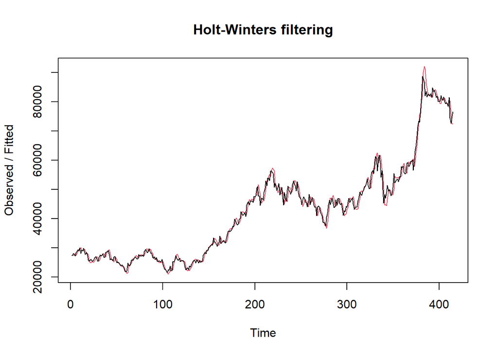

```r
#Lamda=0.6 dan gamma=0.3
des.2<- HoltWinters(train.ts, gamma = FALSE, beta = 0.3, alpha = 0.6)
plot(des.2)
```

```r
#ramalan
ramalandes2<- forecast(des.2, h=104)
ramalandes2
```

```
##     Point Forecast        Lo 80     Hi 80        Lo 95     Hi 95
## 416       74529.19   72201.8614  76856.52   70969.8465  78088.54
## 417       74126.36   71174.7785  77077.95   69612.3038  78640.42
## 418       73723.53   70021.6866  77425.38   68062.0469  79385.02
## 419       73320.70   68766.2647  77875.14   66355.2899  80286.12
## 420       72917.88   67424.1893  78411.56   64516.0077  81319.74
## 421       72515.05   66006.0022  79024.09   62560.3227  82469.77
## 422       72112.22   64519.1207  79705.31   60499.5788  83724.85
## 423       71709.39   62969.0248  80449.75   58342.1567  85076.62
## 424       71306.56   61359.9438  81253.17   56094.5248  86518.59
## 425       70903.73   59695.2640  82112.19   53761.8617  88045.59
## 426       70500.90   57977.7780  83024.02   51348.4386  89653.36
## 427       70098.07   56209.8455  83986.29   48857.8641  91338.27
## 428       69695.24   54393.4986  84996.98   46293.2464  93097.23
## 429       69292.41   52530.5159  86054.30   43657.3052  94927.51
```

[output cut: 90 more lines]

Selanjutnya jika ingin membandingkan plot data latih dan data uji adalah sebagai berikut.

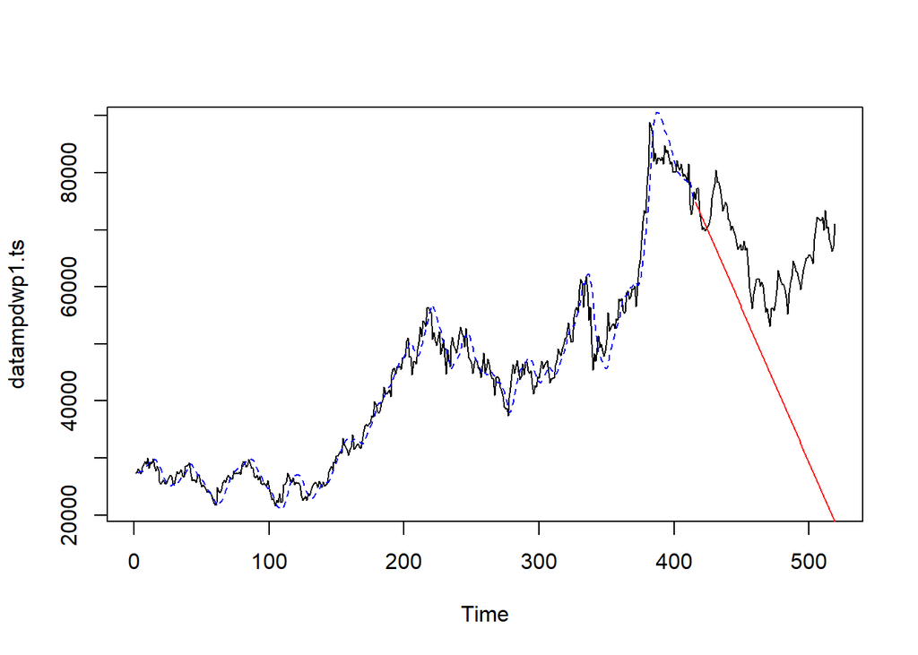

```r
#Visually evaluate the prediction
plot(datampdwp1.ts)
lines(des.1$fitted[,1], lty=2, col="blue")
lines(ramalandes1$mean, col="red")
```

Untuk mendapatkan nilai parameter optimum dari DES, argumen `alpha` dan `beta` dapat dibuat `NULL` seperti berikut.

```r
#Lamda dan gamma optimum
des.opt<- HoltWinters(train.ts, gamma = FALSE)
des.opt
```

```
## Holt-Winters exponential smoothing with trend and without seasonal component.
##
## Call:
## HoltWinters(x = train.ts, gamma = FALSE)
##
## Smoothing parameters:
##  alpha: 0.9431497
##  beta : 0.001982273
##  gamma: FALSE
##
## Coefficients:
##          [,1]
## a 76469.33611
## b    85.35902
```

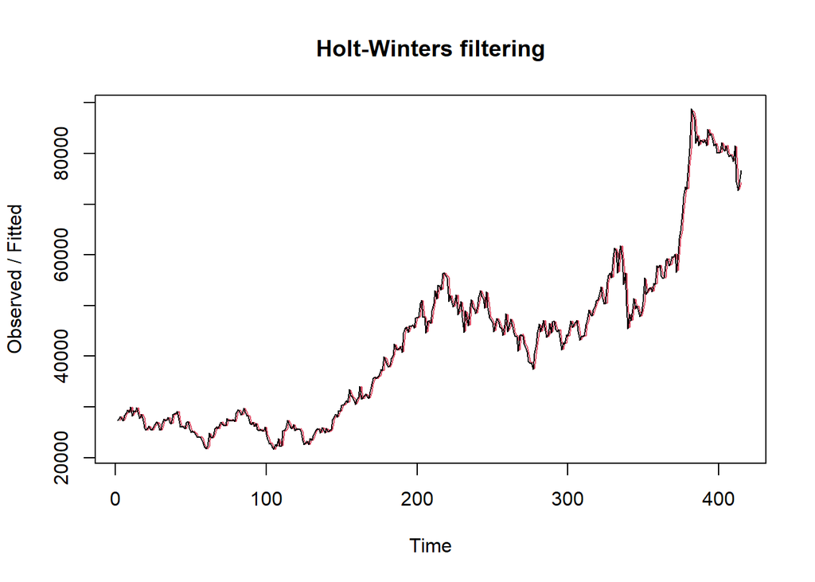

```r
plot(des.opt)
```

```r
#ramalan
ramalandesopt<- forecast(des.opt, h=104)
ramalandesopt
```

```
##     Point Forecast    Lo 80     Hi 80    Lo 95     Hi 95
## 416       76554.70 74428.54  78680.85 73303.03  79806.36
## 417       76640.05 73714.71  79565.40 72166.13  81113.98
## 418       76725.41 73174.26  80276.57 71294.39  82156.44
## 419       76810.77 72726.68  80894.87 70564.69  83056.86
## 420       76896.13 72339.27  81453.00 69927.01  83865.25
## 421       76981.49 71994.88  81968.10 69355.13  84607.85
## 422       77066.85 71683.20  82450.49 68833.28  85300.42
## 423       77152.21 71397.46  82906.96 68351.08  85953.34
## 424       77237.57 71132.91  83342.22 67901.30  86573.84
## 425       77322.93 70886.10  83759.75 67478.65  87167.20
## 426       77408.29 70654.41  84162.17 67079.12  87737.45
## 427       77493.64 70435.79  84551.50 66699.59  88287.70
## 428       77579.00 70228.63  84929.38 66337.57  88820.44
## 429       77664.36 70031.60  85297.13 65991.05  89337.67
```

[output cut: 90 more lines]

Selanjutnya akan dilakukan perhitungan akurasi pada data latih maupun data uji dengan ukuran akurasi SSE, MSE dan MAPE.

#### Akurasi Data Latih

```r
#Akurasi Data Training
ssedes.train1<-des.1$SSE
msedes.train1<-ssedes.train1/length(train.ts)
sisaandes1<-ramalandes1$residuals
head(sisaandes1)
```

```
## Time Series:
## Start = 1
## End = 6
## Frequency = 1
## [1]        NA        NA  720.0000  127.2000 -352.1280  718.4947
```

```r
mapedes.train1 <- sum(abs(sisaandes1[3:length(train.ts)]/train.ts[3:length(train.ts)])
                      *100)/length(train.ts)

akurasides.1 <- matrix(c(ssedes.train1,msedes.train1,mapedes.train1))
row.names(akurasides.1)<- c("SSE", "MSE", "MAPE")
colnames(akurasides.1) <- c("Akurasi lamda=0.2 dan gamma=0.2")
akurasides.1
```

```
##      Akurasi lamda=0.2 dan gamma=0.2
## SSE                     2.992464e+09
## MSE                     7.210755e+06
## MAPE                    4.495002e+00
```

```r
ssedes.train2<-des.2$SSE
msedes.train2<-ssedes.train2/length(train.ts)
sisaandes2<-ramalandes2$residuals
head(sisaandes2)
```

```
## Time Series:
## Start = 1
## End = 6
## Frequency = 1
## [1]        NA        NA  720.0000 -261.6000 -607.1520  803.9146
```

```r
mapedes.train2 <- sum(abs(sisaandes2[3:length(train.ts)]/train.ts[3:length(train.ts)])
                      *100)/length(train.ts)

akurasides.2 <- matrix(c(ssedes.train2,msedes.train2,mapedes.train2))
row.names(akurasides.2)<- c("SSE", "MSE", "MAPE")
colnames(akurasides.2) <- c("Akurasi lamda=0.6 dan gamma=0.3")
akurasides.2
```

```
##      Akurasi lamda=0.6 dan gamma=0.3
## SSE                     1.358770e+09
## MSE                     3.274144e+06
## MAPE                    3.043558e+00
```

Hasil akurasi dari data latih didapatkan skenario 2 dengan lamda=0.6 dan gamma=0.3 memiliki hasil yang lebih baik. Namun untuk kedua skenario dapat dikategorikan peramalan sangat baik berdasarkan nilai MAPE-nya.

#### Akurasi Data Uji

```r
#Akurasi Data Testing
selisihdes1<-ramalandes1$mean-testing$Close
selisihdes1
```

```
## Time Series:
## Start = 416
## End = 519
## Frequency = 1
##   [1]   -487.45763  -2930.32575  -3573.19386    -16.06197   1141.06992
##   [6]   1998.20181   1155.33370   1212.46559    269.59748   -673.27064
##  [11]  -1816.13875  -3459.00686  -7301.87497  -9144.74308 -10787.61119
##  [16] -13830.47930 -12173.34741 -12716.21553 -12259.08364 -11101.95175
##  [21]  -9344.81986 -10587.68797 -12030.55608 -11973.42419 -10116.29230
##  [26] -10259.16042  -9302.02853 -10544.89664 -10187.76475 -10030.63286
##  [31]  -9273.50097  -8616.36908  -9559.23719 -10502.10531 -10144.97342
##  [36] -10687.84153 -12730.70964 -11773.57775 -12616.44586 -10159.31397
##  [41]  -6702.18208  -5845.05019  -4187.91831  -7230.78642  -9073.65453
##  [46] -10916.52264 -11559.39075 -12202.25886 -11445.12697 -12687.99508
##  [51] -12330.86320 -10373.73131  -9016.59942 -10159.46753  -9002.33564
##  [56]  -8145.20375 -11788.07186 -12430.93997 -12573.80809 -14516.67620
##  [61] -17159.54431 -21202.41242 -20645.28053 -20388.14864 -20331.01675
##  [66] -20873.88486 -20516.75298 -19659.62109 -17402.48920 -21645.35731
##  [71] -23988.22542 -25531.09353 -28873.96164 -28616.82975 -28159.69787
##  [76] -28502.56598 -27745.43409 -27488.30220 -27031.17031 -29374.03842
##  [81] -31616.90653 -33159.77464 -34702.64275 -35345.51087 -36488.37898
##  [86] -36831.24709 -36974.11520 -36516.98331 -41359.85142 -43802.71953
##  [91] -46245.58764 -46588.45576 -46931.32387 -47274.19198 -48417.06009
##  [96] -46659.92820 -50702.79631 -48145.66442 -48988.53253 -47231.40065
## [101] -46974.26876 -46317.13687 -47660.00498 -52102.87309
```

```r
SSEtestingdes1<-sum(selisihdes1^2)
MSEtestingdes1<-SSEtestingdes1/length(testing$Close)
MAPEtestingdes1<-sum(abs(selisihdes1/testing$Close)*100)/length(testing$Close)

selisihdes2<-ramalandes2$mean-testing$Close
selisihdes2
```

```
## Time Series:
## Start = 416
## End = 519
## Frequency = 1
##   [1]   -770.8070  -3073.6364  -3576.4659    120.7046   1417.8751   2415.0457
##   [7]   1712.2162   1909.3867   1106.5572    303.7278   -699.1017  -2201.9312
##  [13]  -5904.7607  -7607.5901  -9110.4196 -12013.2491 -10216.0786 -10618.9080
##  [19] -10021.7375  -8724.5670  -6827.3964  -7930.2259  -9233.0554  -9035.8849
##  [25]  -7038.7143  -7041.5438  -5944.3733  -7047.2028  -6550.0322  -6252.8617
##  [31]  -5355.6912  -4558.5207  -5361.3501  -6164.1796  -5667.0091  -6069.8386
##  [37]  -7972.6680  -6875.4975  -7578.3270  -4981.1565  -1383.9859   -386.8154
##  [43]   1410.3551  -1492.4744  -3195.3038  -4898.1333  -5400.9628  -5903.7923
##  [49]  -5006.6217  -6109.4512  -5612.2807  -3515.1102  -2017.9396  -3020.7691
##  [55]  -1723.5986   -726.4281  -4229.2575  -4732.0870  -4734.9165  -6537.7460
##  [61]  -9040.5754 -12943.4049 -12246.2344 -11849.0638 -11651.8933 -12054.7228
##  [67] -11557.5523 -10560.3817  -8163.2112 -12266.0407 -14468.8702 -15871.6996
##  [73] -19074.5291 -18677.3586 -18080.1881 -18283.0175 -17385.8470 -16988.6765
##  [79] -16391.5060 -18594.3354 -20697.1649 -22099.9944 -23502.8239 -24005.6533
##  [85] -25008.4828 -25211.3123 -25214.1418 -24616.9712 -29319.8007 -31622.6302
##  [91] -33925.4597 -34128.2891 -34331.1186 -34533.9481 -35536.7776 -33639.6070
##  [97] -37542.4365 -34845.2660 -35548.0955 -33650.9249 -33253.7544 -32456.5839
## [103] -33659.4134 -37962.2428
```

```r
SSEtestingdes2<-sum(selisihdes2^2)
MSEtestingdes2<-SSEtestingdes2/length(testing$Close)
MAPEtestingdes2<-sum(abs(selisihdes2/testing$Close)*100)/length(testing$Close)

selisihdesopt<-ramalandesopt$mean-testing$Close
selisihdesopt
```

```
## Time Series:
## Start = 416
## End = 519
## Frequency = 1
##   [1]  1254.6951  -559.9458  -574.5868  3610.7722  5396.1312  6881.4903
##   [7]  6666.8493  7352.2083  7037.5673  6722.9264  6208.2854  5193.6444
##  [13]  1979.0034   764.3625  -250.2785 -2664.9195  -379.5605  -294.2014
##  [19]   791.1576  2576.5166  4961.8756  4347.2346  3532.5937  4217.9527
##  [25]  6703.3117  7188.6707  8774.0298  8159.3888  9144.7478  9930.1068
##  [31] 11315.4659 12600.8249 12286.1839 11971.5429 12956.9020 13042.2610
##  [37] 11627.6200 13212.9790 12998.3381 16083.6971 20169.0561 21654.4151
##  [43] 23939.7742 21525.1332 20310.4922 19095.8512 19081.2103 19066.5693
##  [49] 20451.9283 19837.2873 20822.6464 23408.0054 25393.3644 24878.7234
##  [55] 26664.0824 28149.4415 25134.8005 25120.1595 25605.5185 24290.8776
##  [61] 22276.2366 18861.5956 20046.9546 20932.3137 21617.6727 21703.0317
##  [67] 22688.3907 24173.7498 27059.1088 23444.4678 21729.8268 20815.1859
##  [73] 18100.5449 18985.9039 20071.2629 20356.6220 21741.9810 22627.3400
##  [79] 23712.6990 21998.0581 20383.4171 19468.7761 18554.1351 18539.4942
##  [85] 18024.8532 18310.2122 18795.5712 19880.9303 15666.2893 13851.6483
##  [91] 12037.0073 12322.3663 12607.7254 12893.0844 12378.4434 14763.8024
##  [97] 11349.1615 14534.5205 14319.8795 16705.2385 17590.5976 18875.9566
## [103] 18161.3156 14346.6746
```

```r
SSEtestingdesopt<-sum(selisihdesopt^2)
MSEtestingdesopt<-SSEtestingdesopt/length(testing$Close)
MAPEtestingdesopt<-sum(abs(selisihdesopt/testing$Close)*100)/length(testing$Close)

akurasitestingdes <-
  matrix(c(SSEtestingdes1,MSEtestingdes1,MAPEtestingdes1,SSEtestingdes2,MSEtestingdes2,
           MAPEtestingdes2,SSEtestingdesopt,MSEtestingdesopt,MAPEtestingdesopt),
         nrow=3,ncol=3)
row.names(akurasitestingdes)<- c("SSE", "MSE", "MAPE")
colnames(akurasitestingdes) <- c("des ske1","des ske2","des opt")
akurasitestingdes
```

```
##          des ske1     des ske2      des opt
## SSE  6.280566e+10 2.957690e+10 2.880841e+10
## MSE  6.039005e+08 2.843932e+08 2.770039e+08
## MAPE 2.964719e+01 1.900499e+01 2.356731e+01
```

#### Perbandingan SES dan DES

```r
MSEfull <-
  matrix(c(MSEtesting1,MSEtesting2,MSEtestingopt,MSEtestingdes1,MSEtestingdes2,
           MSEtestingdesopt),nrow=3,ncol=2)
row.names(MSEfull)<- c("ske 1", "ske 2", "ske opt")
colnames(MSEfull) <- c("ses","des")
MSEfull
```

```
##                ses       des
## ske 1   8177478200 603900547
## ske 2   6980590227 284393246
## ske opt 7610080000 277003944
```

Kedua metode dapat dibandingkan dengan menggunakan ukuran akurasi yang sama. Contoh di atas adalah perbandingan kedua metode dengan ukuran akurasi MSE. Hasilnya didapatkan metode DES lebih baik dibandingkan metode SES dilihat dari MSE yang lebih kecil nilainya.

## Pemulusan Data Musiman

Pertama impor kembali data baru untuk latihan data musiman.

```r
#Import data
library(rio)
datampdwp1 <- import("https://raw.githubusercontent.com/hakimzoelvamahesa/mpdw/main/Data/harga%20saham%20samsung%202013-2023.csv")
data3.ts <- ts(datampdwp1$Close)
```

Selanjutnya melakukan pembagian data dan mengubahnya menjadi data deret waktu.

```r
#membagi data menjadi training dan testing
training<-datampdwp1[1:415,2]
testing<-datampdwp1[416:519,2]
training.ts<-ts(training, frequency = 7)
testing.ts<-ts(testing, frequency = 7)
```

Kemudian akan dilakukan eskplorasi dengan plot data deret waktu sebagai berikut.

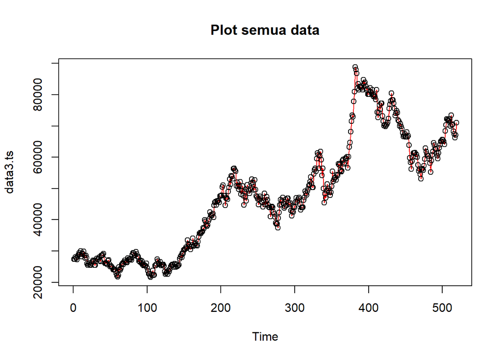

```r
#Membuat plot time series
plot(data3.ts, col="red",main="Plot semua data")
points(data3.ts)
```

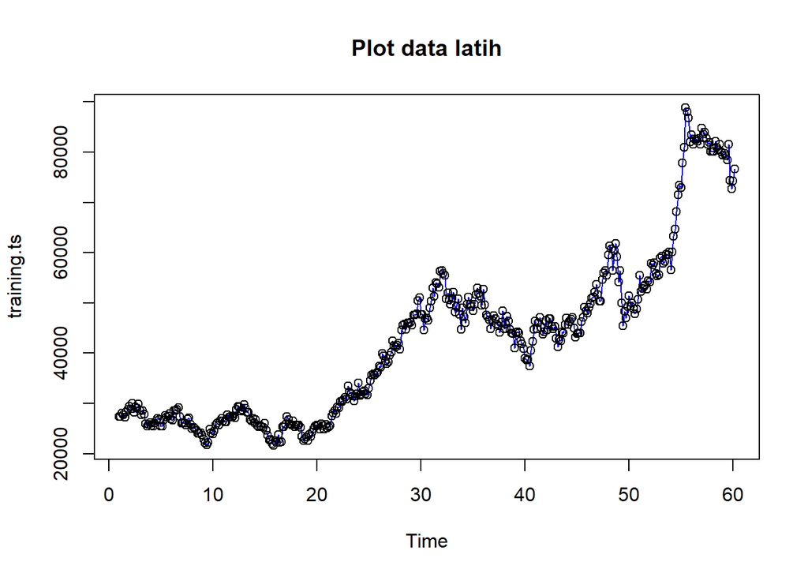

```r
plot(training.ts, col="blue",main="Plot data latih")
points(training.ts)
```

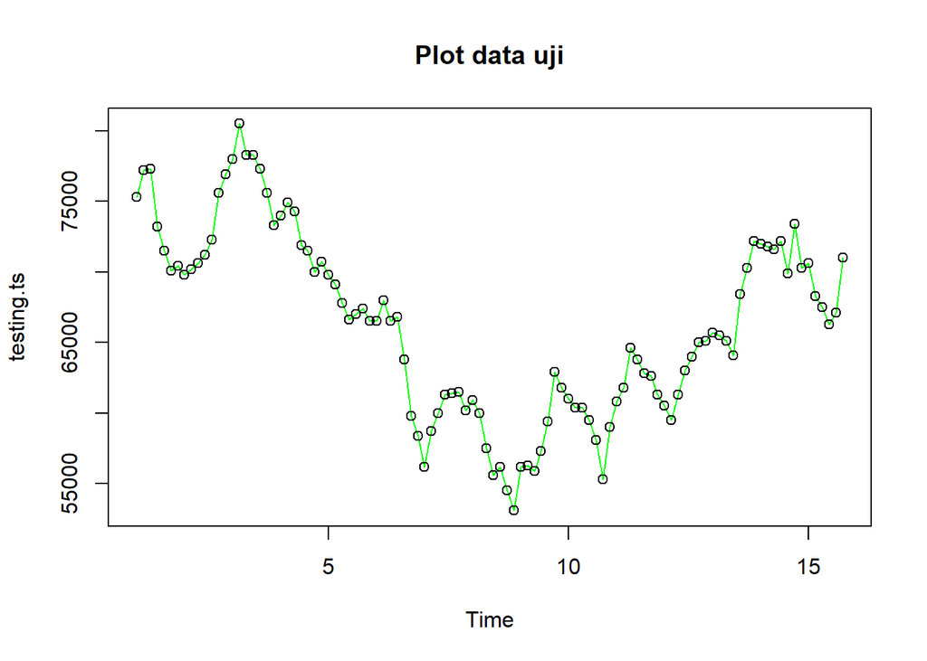

```r
plot(testing.ts, col="green",main="Plot data uji")
points(testing.ts)
```

Pemulusan data musiman dengan metode Winter dilakukan menggunakan fungsi `HoltWinters()` dengan memasukkan argumen tambahan, yaitu `gamma()` dan `seasonal()` . Arguman `seasonal()` diinisialisasi menyesuaikan jenis musiman, aditif atau multiplikatif.

### Winter Aditif

Perhitungan dengan model aditif dilakukan jika plot data asli menunjukkan fluktuasi musiman yang relatif stabil (konstan).

#### Pemulusan

```r
#Pemulusan dengan winter aditif
winter1 <- HoltWinters(training.ts,alpha=0.2,beta=0.1,gamma=0.1,seasonal = "additive")
winter1$fitted
```

```
## Time Series:
## Start = c(2, 1)
## End = c(60, 2)
## Frequency = 7
##               xhat    level       trend        season
##  2.000000 28642.31 27785.00  192.619048   664.6938776
##  2.142857 28276.14 28137.16  208.572789   -69.5918367
##  2.285714 29568.13 28486.50  222.650041   858.9795918
##  2.428571 28387.22 28795.53  231.287413  -639.5918367
##  2.571429 28327.32 28989.37  227.542991  -889.5918367
##  2.714286 29567.08 29399.45  245.796593   -78.1632653
##  2.857143 29919.55 29531.83  234.454972   153.2653061
##  3.000000 30720.55 29758.37  233.664004   728.5088435
##  3.142857 29737.10 29559.93  190.453079   -13.2828299
##  3.285714 30408.20 29362.96  151.711111   893.5290797
##  3.428571 28600.81 29141.03  114.347076  -654.5695252
##  3.571429 28403.37 29119.22  100.730878  -816.5774267
##  3.714286 28650.81 28723.27   51.063461  -123.5297505
##  3.857143 28269.12 28132.18  -13.152696   150.1014345
##  4.000000 28127.13 27633.20  -61.735191   555.6651429
##  4.142857 26904.31 27174.04 -101.477758  -168.2507028
##  4.285714 27428.21 26811.70 -127.563939   744.0729398
##  4.428571 25423.33 26298.49 -166.128078  -709.0343148
##  4.571429 25082.26 26251.70 -154.194682 -1015.2470966
##  4.714286 25896.82 26401.05 -123.839816  -380.3943773
##  4.857143 26347.44 26493.85 -102.176182   -44.2285461
##  5.000000 26781.35 26478.18  -93.525067   396.6948771
##  5.142857 25736.64 26128.39 -119.152143  -272.5954273
##  5.285714 26419.04 25953.91 -124.684954   589.8163839
##  5.428571 25105.05 25885.42 -119.065741  -661.3007329
##  5.571429 25302.35 26265.34  -69.166712  -893.8276339
##  5.714286 26272.75 26595.70  -29.213618  -293.7398394
##  5.857143 26810.85 26823.94   -3.468625    -9.6240877
##  6.000000 27368.40 27054.30   19.914426   294.1865753
##  6.142857 26700.76 26984.54   10.946365  -294.7266729
##  6.285714 27618.56 26995.33   10.931254   612.2932389
##  6.428571 26762.61 27194.55   29.760142  -461.7046203
##  6.571429 26915.48 27583.79   65.708007  -734.0152548
##  6.714286 27952.24 28038.40  104.598351  -190.7598703
##  6.857143 28592.81 28380.55  128.353552    83.9081175
```

[output cut: 358 more lines]

```
## 58.142857 84011.79 83698.52  161.817075   151.4577521
## 58.285714 83289.76 83077.98   83.581223   128.2068731
## 58.428571 83248.70 82943.60   61.785934   243.3136942
## 58.571429 82719.81 82555.65   16.811848   147.3508888
## 58.714286 82057.83 82128.50  -27.584401   -43.0894323
## 58.857143 81439.12 82009.35  -36.740907  -533.4910565
## 59.000000 81402.31 81684.79  -65.523260  -216.9566113
## 59.142857 80951.75 81218.80 -105.569367  -161.4856562
## 59.285714 80795.30 80882.88 -128.604284    41.0257190
## 59.428571 80360.12 80455.22 -158.510359    63.4173505
## 59.571429 79698.74 79924.68 -195.712845   -30.2341095
## 59.714286 79849.82 80089.22 -159.687548   -79.7154532
## 59.857143 77922.27 78839.57 -268.683932  -648.6204708
## 60.000000 76776.16 77526.43 -373.129260  -377.1410374
## 60.142857 75981.79 76658.07 -422.652526  -253.6253242
```

```r
xhat1 <- winter1$fitted[,2]

winter1.opt<- HoltWinters(training.ts, alpha= NULL,  beta = NULL, gamma = NULL, seasonal = "additive")
winter1.opt
```

```
## Holt-Winters exponential smoothing with trend and additive seasonal component.
##
## Call:
## HoltWinters(x = training.ts, alpha = NULL, beta = NULL, gamma = NULL,     seasonal = "additive")
##
## Smoothing parameters:
##  alpha: 0.9276447
##  beta : 0
##  gamma: 0.6265342
##
## Coefficients:
##           [,1]
## a  76509.66714
## b    192.61905
## s1    44.47237
## s2    36.18973
## s3    68.00620
## s4  -640.51487
## s5  -847.57886
## s6  -155.55479
## s7    35.56148
```

```r
winter1.opt$fitted
```

```
## Time Series:
## Start = c(2, 1)
## End = c(60, 2)
## Frequency = 7
##               xhat    level   trend      season
##  2.000000 28642.31 27785.00 192.619  664.693878
##  2.142857 28840.62 28717.59 192.619  -69.591837
##  2.285714 30091.11 29039.51 192.619  858.979592
##  2.428571 28700.64 29147.61 192.619 -639.591837
##  2.571429 28178.84 28875.82 192.619 -889.591837
##  2.714286 30167.27 30052.81 192.619  -78.163265
##  2.857143 29508.51 29162.62 192.619  153.265306
##  3.000000 30593.33 29699.86 192.619  700.855471
##  3.142857 28135.61 28006.27 192.619  -63.273155
##  3.285714 28935.03 27887.56 192.619  854.849508
##  3.428571 27244.06 27713.73 192.619 -662.287359
##  3.571429 27884.51 28533.38 192.619 -841.486344
##  3.714286 26965.17 26903.63 192.619 -131.079060
##  3.857143 26044.16 25681.43 192.619  170.106284
##  4.000000 26485.96 25684.67 192.619  608.678423
##  4.142857 25670.49 25556.35 192.619  -78.487498
##  4.285714 26713.15 25683.59 192.619  836.941815
##  4.428571 24311.81 24750.84 192.619 -631.645129
##  4.571429 25790.12 26528.05 192.619 -930.543704
##  4.714286 27464.34 27471.94 192.619 -200.219642
##  4.857143 27568.73 27215.26 192.619  160.851158
##  5.000000 27461.83 26676.22 192.619  592.994857
##  5.142857 25159.89 25048.95 192.619  -81.682816
##  5.285714 26494.53 25519.97 192.619  781.946092
##  5.428571 25541.60 25903.19 192.619 -554.207645
##  5.571429 27304.06 28005.27 192.619 -893.829543
##  5.714286 28164.57 28194.12 192.619 -222.176450
##  5.857143 28143.63 27825.92 192.619  125.095402
##  6.000000 28563.42 27866.74 192.619  504.059021
##  6.142857 26659.39 26534.85 192.619  -68.077925
##  6.285714 27749.02 26765.14 192.619  791.260519
##  6.428571 27441.79 27710.06 192.619 -460.894022
##  6.571429 28238.59 28939.99 192.619 -894.013638
##  6.714286 29652.09 29709.05 192.619 -249.583273
##  6.857143 29736.93 29426.64 192.619  117.677352
```

[output cut: 358 more lines]

```
## 58.142857 80391.24 80243.50 192.619  -44.878700
## 58.285714 80357.13 80165.95 192.619   -1.444576
## 58.428571 82408.57 82068.10 192.619  147.851633
## 58.571429 81111.99 80954.07 192.619  -34.697021
## 58.714286 80384.96 80578.98 192.619 -386.638048
## 58.857143 81395.83 81898.72 192.619 -695.516811
## 59.000000 80868.70 80796.51 192.619 -120.430232
## 59.142857 79761.24 79626.70 192.619  -58.081408
## 59.285714 80129.99 79855.28 192.619   82.098546
## 59.428571 79554.57 79277.96 192.619   83.996687
## 59.571429 78622.49 78492.31 192.619  -62.440314
## 59.714286 81215.30 81354.24 192.619 -331.556507
## 59.857143 74658.50 75224.68 192.619 -758.793854
## 60.000000 73606.11 73600.50 192.619 -187.010938
## 60.142857 74573.10 74436.80 192.619  -56.324125
```

```r
xhat1.opt <- winter1.opt$fitted[,2]
```

#### Peramalan

```r
#Forecast
forecast1 <- predict(winter1, n.ahead = 104)
forecast1.opt <- predict(winter1.opt, n.ahead = 104)
```

#### Plot Deret Waktu

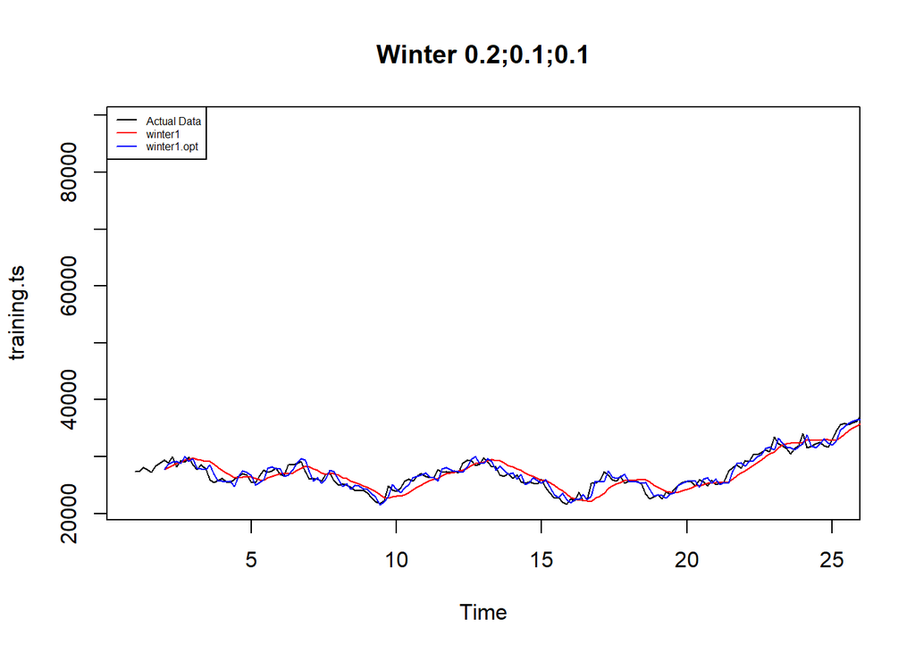

```r
#Plot time series
plot(training.ts,main="Winter 0.2;0.1;0.1",type="l",col="black",
     xlim=c(1,25),pch=12)
lines(xhat1,type="l",col="red")
lines(xhat1.opt,type="l",col="blue")
lines(forecast1,type="l",col="red")
lines(forecast1.opt,type="l",col="blue")
legend("topleft",c("Actual Data",expression(paste(winter1)),
                   expression(paste(winter1.opt))),cex=0.5,
       col=c("black","red","blue"),lty=1)
```

#### Akurasi Data Latih

```r
#Akurasi data training
SSE1<-winter1$SSE
MSE1<-winter1$SSE/length(training.ts)
RMSE1<-sqrt(MSE1)
akurasi1 <- matrix(c(SSE1,MSE1,RMSE1))
row.names(akurasi1)<- c("SSE", "MSE", "RMSE")
colnames(akurasi1) <- c("Akurasi")
akurasi1
```

```
##           Akurasi
## SSE  2.976491e+09
## MSE  7.172268e+06
## RMSE 2.678109e+03
```

```r
SSE1.opt<-winter1.opt$SSE
MSE1.opt<-winter1.opt$SSE/length(training.ts)
RMSE1.opt<-sqrt(MSE1.opt)
akurasi1.opt <- matrix(c(SSE1.opt,MSE1.opt,RMSE1.opt))
row.names(akurasi1.opt)<- c("SSE1.opt", "MSE1.opt", "RMSE1.opt")
colnames(akurasi1.opt) <- c("Akurasi")
akurasi1.opt
```

```
##                Akurasi
## SSE1.opt  1.207574e+09
## MSE1.opt  2.909817e+06
## RMSE1.opt 1.705819e+03
```

```r
akurasi1.train = data.frame(Model_Winter = c("Winter 1","Winter1 optimal"),
                            Nilai_SSE=c(SSE1,SSE1.opt),
                            Nilai_MSE=c(MSE1,MSE1.opt),Nilai_RMSE=c(RMSE1,RMSE1.opt))
akurasi1.train
```

```
##      Model_Winter  Nilai_SSE Nilai_MSE Nilai_RMSE
## 1        Winter 1 2976491323   7172268   2678.109
## 2 Winter1 optimal 1207573982   2909817   1705.819
```

#### Akurasi Data Uji

```r
#Akurasi Data Testing
forecast1<-data.frame(forecast1)
testing.ts<-data.frame(testing.ts)
selisih1<-forecast1-testing.ts
SSEtesting1<-sum(selisih1^2)
MSEtesting1<-SSEtesting1/length(testing.ts)

forecast1.opt<-data.frame(forecast1.opt)
selisih1.opt<-forecast1.opt-testing.ts
SSEtesting1.opt<-sum(selisih1.opt^2)
MSEtesting1.opt<-SSEtesting1.opt/length(testing.ts)
```

### Winter Multiplikatif

Model multiplikatif digunakan cocok digunakan jika plot data asli menunjukkan fluktuasi musiman yang bervariasi.

#### Pemulusan

```r
#Pemulusan dengan winter multiplikatif
winter2 <- HoltWinters(training.ts,alpha=0.2,beta=0.1,gamma=0.3,seasonal = "multiplicative")
winter2$fitted
```

```
## Time Series:
## Start = c(2, 1)
## End = c(60, 2)
## Frequency = 7
##               xhat    level       trend    season
##  2.000000 28626.92 27785.00  192.619048 1.0232077
##  2.142857 28279.79 28136.55  208.511898 0.9976974
##  2.285714 29556.82 28485.42  222.548359 1.0295684
##  2.428571 28389.92 28794.06  231.157367 0.9781120
##  2.571429 28296.15 28986.39  227.274063 0.9685932
##  2.714286 29577.40 29408.55  246.763092 0.9973727
##  2.857143 29936.94 29539.53  235.184659 1.0054486
##  3.000000 30901.66 29763.39  234.051945 1.0301432
##  3.142857 29838.34 29542.81  188.589182 1.0035969
##  3.285714 30453.51 29325.19  147.968439 1.0332623
##  3.428571 28528.34 29102.78  110.930252 0.9765395
##  3.571429 28495.72 29089.12   98.471095 0.9762958
##  3.714286 28495.56 28659.94   45.705898 0.9926815
##  3.857143 28214.24 28090.03  -15.855863 1.0049894
##  4.000000 27844.80 27601.68  -63.104988 1.0111200
##  4.142857 26749.87 27201.36  -96.826080 0.9869149
##  4.285714 27219.06 26871.51 -120.128449 1.0174823
##  4.428571 25511.70 26413.48 -153.918944 0.9715204
##  4.571429 25033.64 26364.20 -143.454913 0.9547266
##  4.714286 25554.53 26548.87 -110.642240 0.9665749
##  4.857143 26234.80 26733.18  -81.146965 0.9843451
##  5.000000 26588.06 26762.81  -70.069560 0.9960784
##  5.142857 25766.20 26474.27  -91.916488 0.9766450
##  5.285714 26270.30 26319.65  -98.186835 1.0018625
##  5.428571 25592.28 26307.24  -89.608851 0.9761476
##  5.571429 25753.50 26628.99  -48.473312 0.9688863
##  5.714286 26328.66 26899.75  -16.550079 0.9793722
##  5.857143 26851.03 27134.66    8.595433 0.9892342
##  6.000000 27025.16 27371.50   31.420505 0.9862147
##  6.142857 26694.17 27381.60   29.287833 0.9738529
##  6.285714 27600.17 27412.08   29.407603 1.0057826
##  6.428571 27521.48 27632.35   48.493802 0.9942426
##  6.571429 27475.00 27889.75   69.384578 0.9826842
##  6.714286 28062.66 28241.02   97.572624 0.9902631
##  6.857143 28650.65 28556.18  119.331267 0.9991333
```

[output cut: 358 more lines]

```
## 58.142857 83535.59 81773.86  186.776290 1.0192159
## 58.285714 83237.79 81286.48  119.360042 1.0225039
## 58.428571 83346.74 81202.85   99.061135 1.0251511
## 58.571429 82344.62 80844.08   53.277861 1.0178902
## 58.714286 81812.11 80534.91   17.033831 1.0156442
## 58.857143 80476.90 80510.18   12.856878 0.9994270
## 59.000000 80950.37 80427.60    3.313471 1.0064584
## 59.142857 80821.98 80122.83  -27.494900 1.0090723
## 59.285714 81396.95 79892.78  -47.750743 1.0194367
## 59.428571 80787.58 79433.63  -88.890075 1.0181844
## 59.571429 79737.67 78895.40 -133.824494 1.0123931
## 59.714286 80196.81 79109.72  -99.009400 1.0150119
## 59.857143 77500.26 77868.50 -213.230973 0.9980040
## 60.000000 76522.46 76693.30 -309.428277 1.0018144
## 60.142857 76040.07 75940.18 -353.796953 1.0060022
```

```r
xhat2 <- winter2$fitted[,2]

winter2.opt<- HoltWinters(training.ts, alpha= NULL,  beta = NULL, gamma = NULL, seasonal = "multiplicative")
winter2.opt$fitted
```

```
## Time Series:
## Start = c(2, 1)
## End = c(60, 2)
## Frequency = 7
##               xhat    level   trend    season
##  2.000000 28626.92 27785.00 192.619 1.0232077
##  2.142857 28834.43 28708.35 192.619 0.9976974
##  2.285714 30091.99 29035.15 192.619 1.0295684
##  2.428571 28696.07 29145.61 192.619 0.9781120
##  2.571429 28151.64 28871.84 192.619 0.9685932
##  2.714286 30210.78 30097.74 192.619 0.9973727
##  2.857143 29526.65 29174.03 192.619 1.0054486
##  3.000000 30622.32 29689.82 192.619 1.0247599
##  3.142857 28167.18 28031.80 192.619 0.9979722
##  3.285714 28904.08 27886.08 192.619 1.0293955
##  3.428571 27308.08 27753.46 192.619 0.9771704
##  3.571429 27869.62 28521.93 192.619 0.9705749
##  3.714286 26927.35 26867.37 192.619 0.9950982
##  3.857143 26036.02 25685.52 192.619 1.0061008
##  4.000000 26428.28 25698.98 192.619 1.0207279
##  4.142857 25753.51 25631.89 192.619 0.9972506
##  4.285714 26617.60 25682.96 192.619 1.0286765
##  4.428571 24526.29 24876.51 192.619 0.9783461
##  4.571429 25775.05 26473.11 192.619 0.9665981
##  4.714286 27419.95 27450.55 192.619 0.9919248
##  4.857143 27583.80 27235.31 192.619 1.0056828
##  5.000000 27426.28 26692.95 192.619 1.0201116
##  5.142857 25263.77 25149.13 192.619 0.9969230
##  5.285714 26389.48 25522.75 192.619 1.0262144
##  5.428571 25700.18 25993.62 192.619 0.9814384
##  5.571429 27264.74 27966.31 192.619 0.9682451
##  5.714286 28130.69 28192.41 192.619 0.9910395
##  5.857143 28161.22 27855.50 192.619 1.0040325
##  6.000000 28521.54 27882.14 192.619 1.0159139
##  6.142857 26746.49 26625.09 192.619 0.9973444
##  6.285714 27692.05 26774.84 192.619 1.0268691
##  6.428571 27522.79 27744.72 192.619 0.9851613
##  6.571429 28176.11 28905.50 192.619 0.9683136
##  6.714286 29638.32 29747.59 192.619 0.9899167
##  6.857143 29779.00 29477.30 192.619 1.0036763
```

[output cut: 358 more lines]

```
## 58.142857 80491.22 81134.94 192.619 0.9897165
## 58.285714 80474.12 80964.06 192.619 0.9915896
## 58.428571 82533.11 82757.22 192.619 0.9949762
## 58.571429 81285.59 81532.91 192.619 0.9946169
## 58.714286 80080.16 80999.20 192.619 0.9863082
## 58.857143 81161.74 82608.83 192.619 0.9801971
## 59.000000 80882.11 81711.56 192.619 0.9875212
## 59.142857 79865.23 80524.04 192.619 0.9894517
## 59.285714 80261.09 80656.03 192.619 0.9927325
## 59.428571 79665.75 79958.39 192.619 0.9939457
## 59.571429 78796.28 79072.49 192.619 0.9940854
## 59.714286 80919.27 81766.17 192.619 0.9873165
## 59.857143 74513.56 75886.82 192.619 0.9794179
## 60.000000 73563.55 74376.68 192.619 0.9865125
## 60.142857 74649.20 75255.78 192.619 0.9894074
```

```r
xhat2.opt <- winter2.opt$fitted[,2]
```